# Exercise 4 - Likage Disequilibrium

Mahdi Robbani

March 8, 2020

# Linkage Disequilibrium in Small and Large Populations of Gorillas

**Peter Frandsen**

## Program

- Apply filters to prepare data for analysis
- Explore patterns of LD blocks in two populations of gorilla
- Estimate mean pairwise LD between SNP’s along a chromosome
- Plot and compare curves of LD decay in two populations of gorilla

## Learning outcome

- Get familiar with common filtering procedures in genome analyses using PLINK
- Get familiar with running analyses in R and the code involved
- Understand the processes that builds and breaks down LD
- Understand the link between patterns of LD and population history

## Essential background reading

Nielsen and Slatkin: Chapter 6 - Linkage Disequilibrium and Gene Mapping p. 107-126

## Key concepts that you should familiarize with:

- Definition of linkage disequilibrium (LD)
- Measures of LD
- Build-up and breakdown of LD
- Applications of LD in population genetics

### Suggestive reading

Prado-Martinez et al. (2014) [Great ape genetic diversity and population history](http://www.nature.com/nature/journal/v499/n7459/full/nature12228.html)

# Introduction

[figure not shown]

**Figure 1 Distribution range of the *Gorilla* genus.** The large yellow patch indicates the distribution of western lowland gorilla (*Gorilla gorilla gorilla*). The distribution of mountain gorilla (*Gorilla beringei beringei*) is encircled with red. Reprint from [http://maps.iucnredlist.org,](http://maps.iucnredlist.org/) edited by Peter Frandsen.

## Getting started

Start by downloading the compressed folder ‘gorillas.tar.gz’ to your exercise folder unzip, and navigate to the folder ‘LD’ with the following commands: (We assume that the folder /exercises exists in your home folder; otherwise create it `mkdir ~/exercises`)

```bash
cd ~/exercises
mkdir LD
cd LD/
cp ~/groupdirs/SCIENCE-BIO-Popgen_Course/exercises/LD/gorillas.tar.gz .
tar -zxvf gorillas.tar.gz
rm gorillas.tar.gz
```

All code needed in the exercise is given below. It will be indicated with an **>R** when you need to run a command in R, otherwise stay in your main terminal.

## LD blocks

In this first part of the exercise we will explore a specific region of chromosome 4 in terms of blocks of LD. We have not chosen this region for any specific region and the emerging patterns should serve as a general comparison of LD in the two populations. First step will be to extract a pre-defined region using PLINK and run a LD anaysis with SnpMatrix in R. The results will be written to an .eps file that you can open with Adobe.

### Mountain Gorilla

```bash
plink --file mountain --maf 0.15 --geno 0 --thin 0.25 --from 9029832 --to 14148683 --make-bed --out mountainBlock
```

#### >R

```r
library(snpMatrix)
data <- read.plink("mountainBlock")
ld <- ld.snp(data, dep=930)
plot.snp.dprime(ld, filename="Mountain.eps", res=100)
q()
```

### Western Lowland Gorilla

```bash
plink --file lowland --maf 0.15 --geno 0 --thin 0.25 --from 9029832 --to 14148683 --make-bed --out lowlandBlock
```

#### >R

```r
library(snpMatrix)
data<- read.plink("lowlandBlock")
ld<- ld.snp(data, dep=2268)
plot.snp.dprime(ld, filename="WesternLowland.eps", res=100)
q()
```

**NB**: the .eps files are quite heavy and loading the output could take a long time. You can start to open the .eps file with the commands

```bash
evince Mountain.eps & # the ‘&’ will make the command run in the background
evince WesternLowland.eps &
```

**NB**: this will take approximately five minutes to load.*

**Q1:** How would you characterize the structure you observe in the different populations?

**Answer:**

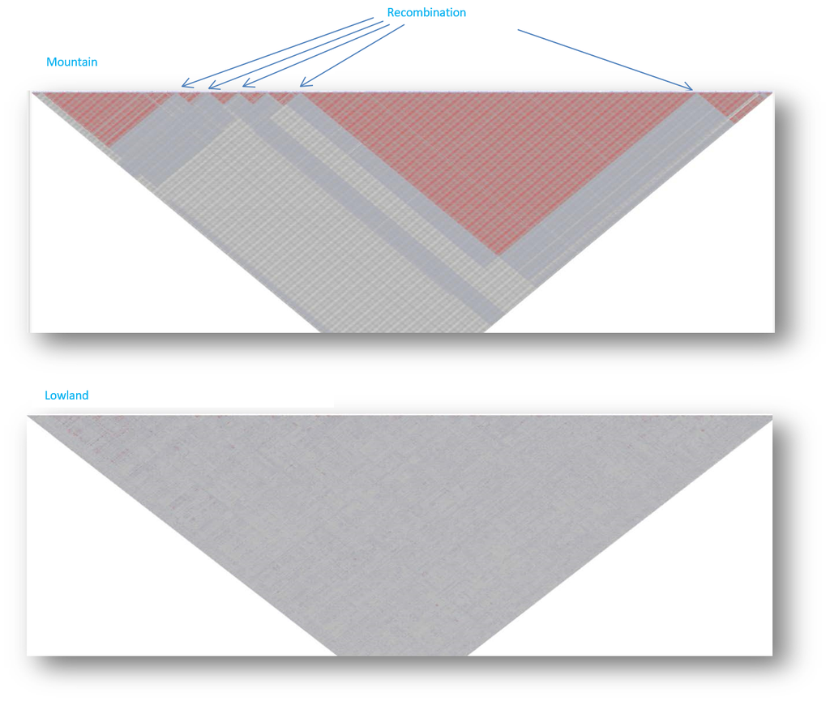

The mountain gorilla genome consists of large regions with blocks of high LD, while recombination has broken down such patterns in the western lowland gorilla.

**Q2:** How many (if any) recombination hotspots can you identify in the two populations (crude estimate)?

Mountain gorilla:

Western lowland gorilla:

## LD decay

In this part of today’s exercise we will explore the decay of LD as a function of distance along the chromosome. This will enable us to compare the two populations in terms of mean distances on the chromosome with sites in LD. To begin with, we will do some essential filtering procedures common to this type of analysis and then, again, read the data into R and run the analyses with snpMatrix.

### Filtering

```bash
plink --file mountain --maf 0.15 --geno 0 --thin 0.15 --make-bed --out mountainLD
plink --file lowland --maf 0.15 --geno 0 --thin 0.15 --make-bed --out lowlandLD
```

**Q3:** Why do we exclude minor allele frequencies (i.e. the less common or rare alleles in the population)?

Newly arisen and rare mutations will distort the LD pattern (elevate the mean LD) Remember, every new mutation on a chromosome is in complete LD with the rest of the chromosome. For most LD analyses, we are also more interested in the common variation. On the plus side, we also get rid of sequencing errors (which are also rare, hopefully).

**Q4:** What else are we filtering away? See list of options in PLINK http://[http://pngu.mgh.harvard.edu/\~purcell/plink/reference.shtml#options](http://pngu.mgh.harvard.edu/%7Epurcell/plink/reference.shtml#options) Seems to be broken.

`--geno 0` : removes all missing data

`--thin 0.15` : removes a random 85 percent of the data (keeps 15 percent), otherwise we would not get through the exercise in just two hours. Plus, it is not always necessary to keep all your data. Sometimes, only a fraction of your data will tell you the same story as a complete and computational heavy dataset.

**Q5:** How many SNP’s did we have before and after filtering?

mountain gorilla: 2.521.457 SNP’s before, 23,689 SNP’s after filtering

lowland gorilla: 2.521.457 SNP’s before, 48,555 SNP’s after filtering

In other words, you threw away a lot of data (but you can still reach the same conclusion as if we had looked at the whole genome)

### Mountain Gorilla

**>R** *(paste in the whole script)*

```r
library("snpMatrix")
data<- read.plink("mountainLD")
ld<- ld.snp(data, dep=500)
do.rsq2 <- ("rsq2" %in% names(ld))
snp.names <- attr(ld, "snp.names")
name<- c("#M1", "#M2", "rsq2", "Dprime", "lod")
r.maybe <- ld$rsq2
max.depth <- dim(ld$dprime)[2]
res<-matrix(NA,ncol=3,nrow=length(snp.names)*max.depth)
count<-1
for (i.snp in c(1:(length(snp.names) - 1))) {
     for (j.snp in c((i.snp + 1):length(snp.names))) {
          step <- j.snp - i.snp
          if (step > max.depth) {
              break
             }
          res[count,]<-c(snp.names[i.snp], snp.names[j.snp],r.maybe[i.snp, step])
          count<-count+1;
          }
     }
resNum<-as.numeric(res)#converts to numeric values
dim(resNum)<-dim(res)
dis<- resNum[,2]-resNum[,1] #calculates distances between sites
disbin<- cut(dis, br=seq(0,2000000,by=10000))
#cuts distances into bins of size 1K from distance "0" to "2000000"
res<- tapply(resNum[,3], disbin, mean, na.rm=T)
#takes the mean of r2 (3rd column in resNum) in each bin, removes "NA", and distances >2K
pdf("MountainLDdecay.pdf") #saves output as a .pdf
plot(res, type="l", ylim=c(0, 1))
dev.off()
### The following code is just a way to store the LD calculations ###
ressum<- tapply(resNum[,3], disbin, sum, na.rm=T)
func<- function(x)#makes a function "x"
               length(x[!is.na(x)])
#gives the lengths of what is not (denoted by "!") "NA" in "x"
reslength<- tapply(resNum[,3], disbin, func)
#gives the length in each bin of 1K for each value of r2
write.table(reslength, file="MountainLength.txt")
write.table(ressum, file="MountainSum.txt")
q()
n
```

Look through the script to get an idea about what is going on.

**Q6:** How many pair-wise comparisons have we done (*dep* in snpMatrix)?

500 (ld<- ld.snp(data, dep=500))

### Western Lowland Gorilla

**>R** *(paste in the whole script)*

```r
library("snpMatrix")
data<- read.plink("lowlandLD")
ld<- ld.snp(data, dep=500)
do.rsq2 <- ("rsq2" %in% names(ld))
snp.names <- attr(ld, "snp.names")
name<- c("#M1", "#M2", "rsq2", "Dprime", "lod")
r.maybe <- ld$rsq2
max.depth <- dim(ld$dprime)[2]
res<-matrix(NA,ncol=3,nrow=length(snp.names)*max.depth)
count<-1
for (i.snp in c(1:(length(snp.names) - 1))) {
     for (j.snp in c((i.snp + 1):length(snp.names))) {
          step <- j.snp - i.snp
          if (step > max.depth) { break
             }
         res[count,]<-c(snp.names[i.snp], snp.names[j.snp],r.maybe[i.snp, step])
         count<-count+1;
         }
     }
resNum<-as.numeric(res)#converts to numeric values
dim(resNum)<-dim(res)
dis<- resNum[,2]-resNum[,1] #calculates distances between sites
disbin<- cut(dis, br=seq(0,2000000,by=10000))
#cuts distances into bins of size 1K from distance "0" to "2000000"
res<- tapply(resNum[,3], disbin, mean, na.rm=T)
#takes the mean of r2 (3rd column in resNum) in each bin, removes "NA", and distances >2K
pdf("WesternLowlandLDdecay.pdf")
#saves output as a .pdf file
plot(res, type="l", ylim=c(0, 1))
dev.off()
### The following code is just a way to store the LD calculations ###
ressum<- tapply(resNum[,3], disbin, sum, na.rm=T)
func<- function(x)#makes a function "x"
       length(x[!is.na(x)])
#gives the lengths of what is not (denoted by "!") "NA" in "x"
reslength<- tapply(resNum[,3], disbin, func)
#gives the length in each bin of 1K for each value of r2
write.table(reslength, file="LowlandLength.txt")
write.table(ressum, file="LowlandSum.txt")
q()
n
```

Extra task (optional): when done with both populations, plot the curves together with different colors and legend (*hint: the input you will need was printed to four text files in the end of the scripts above*).

**Q7:** Look at the two plots and explain why LD decays with distance.

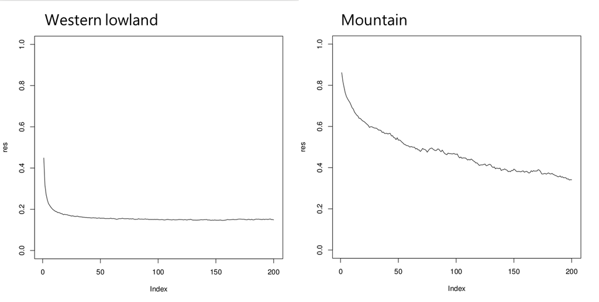

LD is broken down by recombination, with increasing distance between two sites, the likelihood of a recombination event increases. See plots above.

**Q8:** What is the mean *r2* at distance 1M (100 on the x-axis) in the two populations?

Mountain gorilla:

Western lowland gorilla:

Mountain gorilla: ~0.45

Western lowland gorilla: ~0.15

**Q9:** What could explain any observed difference in the decay of LD in the two populations?

Selection (genetic hitchhiking), admixture, and drift in course of the population history

**Q10:** These estimates are done on an autosomal chromosome, would you expect different LD patterns in other parts of the genome?

Yes, there is no (or very little) recombination on the Y chromosome and the mitochondria; hence, you would not observe a decay with increasing distance.

## Perspectives

**Q11:** In comparison to the different populations of gorilla, how do you think the trajectory of the LD decay and the LD block patterns would look like in humans?

LD decays at a rate similar to the western lowland gorilla and large parts of the genome will show comparable patterns in terms of LD blocks. Only for very small human population, that has been isolated for a long time, would we observe anything as extreme as in the mountain gorilla.

**Q12:** Would you also expect different patterns of LD in human populations (*e.g.* Chinese, Europeans, and Africans)?

Populations that have gone through historic bottlenecks, been subjected to genetic drift, admixture or selection will on average have a higher degree of LD. As an example, populations that went through a bottleneck when they migrated out of African (*e.g.* Europeans), have on average a higher degree of LD compared to most African populations.